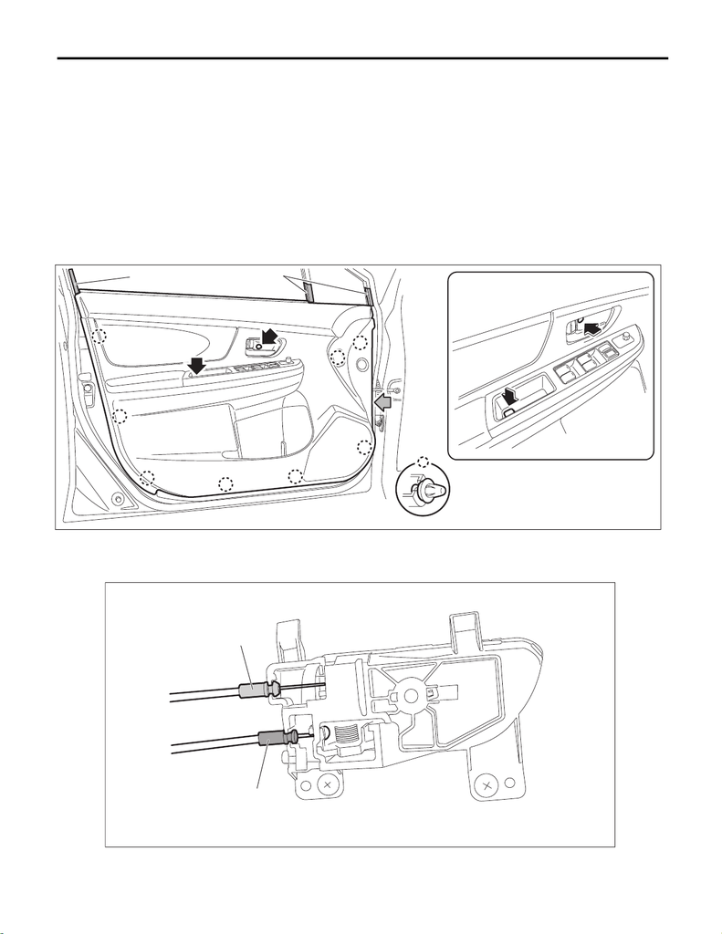

EI-56

Door Trim

EXTERIOR/INTERIOR TRIM

17.Door Trim

A: REMOVAL

1. FRONT DOOR

1) Disconnect the ground cable from battery and wait for at least 60 seconds before starting work. <Ref. to

NT-5, BATTERY, NOTE, Note.>

NOTE:

For models other than STI model, disconnect the ground terminal from battery sensor.

2) Remove the trim panel - front door.

(1) Attach the protective tape (a).

(2) Open the cover and remove the screw.

(3) Remove the clips, and remove the trim panel - front door from the panel assembly - front door.

NOTE:

It is easier to remove the door trim if the removal is performed from the gray arrow section.

(4) Detach the door lock cable (a) and door open cable (b) from the remote assembly - door.

(5) Disconnect the harness connector and remove the trim panel - front door.

EI-04178

(a)

(a)

EI-03501

(b)

(a)

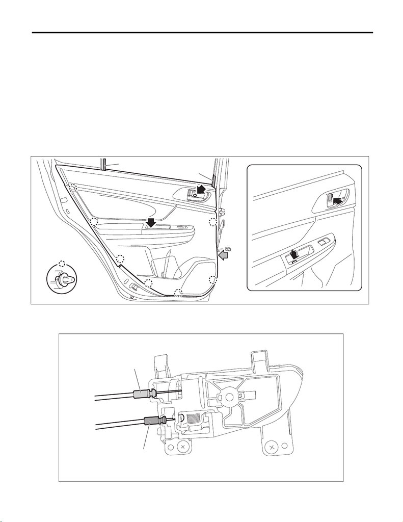

EI-57

Door Trim

EXTERIOR/INTERIOR TRIM

3) Remove each part as required.

• Remote assembly - door: <Ref. to SL-32, REMOVAL, Front Inner Remote.>

• Switch - power window main: <Ref. to GW-11, MAIN SWITCH, REMOVAL, Power Window Control

Switch.>

• Weather strip - door INN: <Ref. to EI-59, DISASSEMBLY, Door Trim.>

2. REAR DOOR

1) Disconnect the ground cable from battery. <Ref. to NT-5, BATTERY, NOTE, Note.>

NOTE:

For models other than STI model, disconnect the ground terminal from battery sensor.

2) Remove the trim panel - rear door.

(1) Attach the protective tape (a).

(2) Open the cover and remove the screw.

(3) Remove the clips, and remove the trim panel - rear door from the panel assembly - rear door.

NOTE:

It is easier to remove the door trim if the removal is performed from the gray arrow section.

(4) Detach the door lock cable (a) and door open cable (b) from the remote assembly - door.

(5) Disconnect the harness connector and remove the trim panel - rear door.

EI-04308

(a)

(a)

EI-03501

(b)

(a)

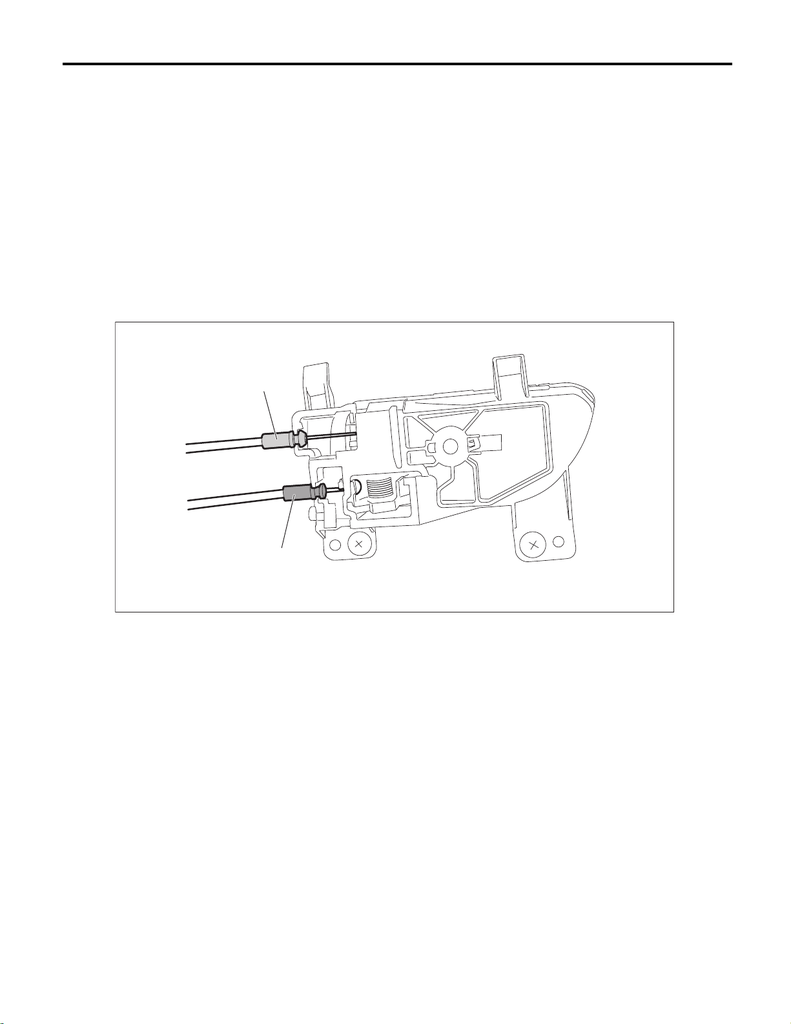

EI-58

Door Trim

EXTERIOR/INTERIOR TRIM

3) Remove each part as required.

• Remote assembly - door: <Ref. to SL-40, REMOVAL, Rear Inner Remote.>

• Switch - power window sub: <Ref. to GW-12, SUB-SWITCH, REMOVAL, Power Window Control Switch.>

• Weather strip - door INN: <Ref. to EI-59, DISASSEMBLY, Door Trim.>

B: INSTALLATION

1) Before installation, check the following items.

• Cable is free from deformation such as fray.

• Grease is applied sufficiently to cable joints.

If grease is insufficient, add it as necessary before assembling the cable.

2) Install the removed parts to the trim panel - door.

3) Install the trim panel - door.

NOTE:

Attach the door lock cable (a - end ball: small) to the upper side, and attach the door open cable (b - end ball:

large) to the lower side.

4) Connect the battery ground terminal. <Ref. to NT-5, BATTERY, NOTE, Note.>

NOTE:

For models other than STI model, connect the ground terminal to battery sensor.

EI-03501

(b)

(a)

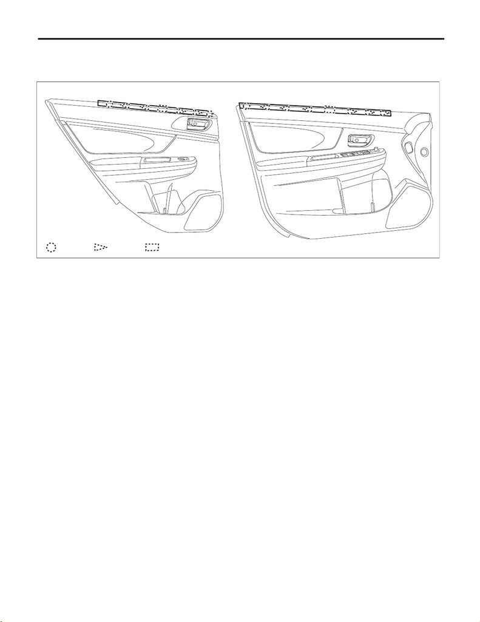

EI-59

Door Trim

EXTERIOR/INTERIOR TRIM

C: DISASSEMBLY

1) Remove the trim panel - door.

2) Disengage the rivets and claws, and remove the weather strip - door INN from the trim panel - door.

NOTE:

Remove the rivets with a rivet cutter or nipper, etc.

(a) Rivet (b) Claw (c) Claw

EI-03433

(a): (b): (c):

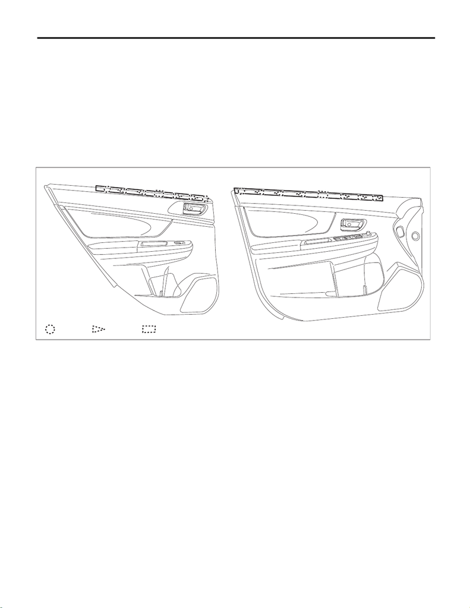

EI-60

Door Trim

EXTERIOR/INTERIOR TRIM

D: ASSEMBLY

1) Bend the claws while pushing the weather strip - door INN against the trim panel - door.

CAUTION:

Beware of the direction of folding the claws.

2) Install the rivet.

CAUTION:

Set the height of rivet crimped section as 3 mm (0.12 in). If the crimp is not sufficient, press it with pli-

ers, etc. in order not to interfere the trim panel - door.

Preparation tool and item:

Hand riveter (corresponding to

φ

3.2 mm (0.13 in))

Rivet

3) After installing the weather strip - door INN, perform the following checks.

• Make sure there are no gaps between the weather strip - door INN and the trim panel - door.

• Make sure there are no looseness when pulling the weather strip - door INN lightly.

(a) Rivet (b) Direction of folding claws (c) Claw bending direction: bend for-

ward for LH side, backward for RH

side.

EI-03433

(a): (b): (c):